## Supplementary details supporting the analysis of OSL and C14 dates, lithics and shellfish from the 1989 excavations at Madjebebe (Malakanunja II)

#### Ben Marwick, benmarwick@gmail.com

This document contains the source code used to generate the plots and statistics presented in the manuscript. It is provided to give the reader additional insight into the data analysis workflow and allow anyone to reproduce our analysis and further explore the analyses and data for themselves.

## OSL and C14 dates

```r
library(mjb1989excavationpaper)
chrono_data <- get_chrono_data()
```

OK, let’s have a look at what `get_chrono_data` actually does. You can print the body of any function by calling it without a parenthesis.

```r
get_chrono_data
```

```
function ()
{
    dates_1989 <- read.csv("data/Date_table_from_paper_on_1989_dig.csv")
    return(dates_1989)
}
<environment: namespace:mjb1989excavationpaper>
```

And let’s have a quick at the raw data too:

| Square | Spit | Method | Lab.Code | Type | Depth.cm | Uncalibrated.Age | Error | Lower.Cal.BP | Upper.Cal.BP | Reference |
| --- | --- | --- | --- | --- | --- | --- | --- | --- | --- | --- |
| DEF30 | NA | TL | KTL156 | Multigrain | 2 | 2000 | 1300 | NA | NA | Roberts et al. 1990a |
| 1972 | 2 | C14 | SUA263 | Wood Charcoal | 10 | 450 | 80 | 635 | 309 | This paper |
| F30 | 4 | C14 | ANU-7002 | Marine gastropod | 13 | 3810 | 80 | 4420 | 3981 | This paper |
| F30 | 12 | C14 | ANU-7003 | Marine gastropod | 59 | 6290 | 90 | 7420 | 6995 | This paper |
| 1972 | 8 | C14 | SUA264 | Wood Charcoal | 65-88 | 6440 | 200 | 7689 | 6883 | This paper |
| F30 | 18 | C14 | ANU-7004 | Wood Charcoal | 93 | 7300 | 230 | 8558 | 7676 | This paper |
| DEF30 | 21 | C14 | ANU-7005 | Wood Charcoal | 113 | 10470 | 120 | 12681 | 12006 | This paper |
| DEF30 | 26 | ABOX | ANU-7006 | Wood Charcoal and Sand | 146 | 13390 | 400 | 17429 | 15001 | Bird et al. 2002 |
| DEF30 | NA | TL | KTL165 | Multigrain | 155 | 15000 | 3000 | NA | NA | Roberts et al. 1990a |
| DEF30 | NA | ABOX | ANUA-9913 | Wood Charcoal | 149 | 10330 | 150 | 12638 | 11501 | Bird et al. 2002 |

[output cut: 14 more lines]

### `chrono_data_tidied`

Let’s see the `chrono_data_tidied` data

|  | Lab.Code | Square | Spit | Method | Type | Depth.cm | Uncalibrated.Age | Error | Lower.Cal.BP | Upper.Cal.BP | Reference | Depth.m | Unmodelled..BP. | X | X.1 | X.2 | X.3 | age2plot |
| --- | --- | --- | --- | --- | --- | --- | --- | --- | --- | --- | --- | --- | --- | --- | --- | --- | --- | --- |
| 1 | ANU-7002 | F30 | 4 | C14 | Marine gastropod | 13 | 3810 | 80 | 4420 | 3981 | This paper | 0.130 | 4420 | 3981 | 95.4 | 122 | 4209 | 4.209 |
| 2 | ANU-7003 | F30 | 12 | C14 | Marine gastropod | 59 | 6290 | 90 | 7420 | 6995 | This paper | 0.590 | 7420 | 6995 | 95.4 | 114 | 7209 | 7.209 |
| 3 | ANU-7004 | F30 | 18 | C14 | Wood Charcoal | 93 | 7300 | 230 | 8558 | 7676 | This paper | 0.930 | 8558 | 7676 | 95.4 | 225 | 8127 | 8.127 |
| 4 | ANU-7005 | DEF30 | 21 | C14 | Wood Charcoal | 113 | 10470 | 120 | 12681 | 12006 | This paper | 1.130 | 12681 | 12006 | 95.4 | 186 | 12358 | 12.358 |
| 5 | ANU-7006 | DEF30 | 26 | ABOX | Wood Charcoal and Sand | 146 | 13390 | 400 | 17429 | 15001 | Bird et al. 2002 | 1.460 | 17429 | 15001 | 95.4 | 606 | 16132 | 16.132 |
| 6 | ANU-7007 | DEF30 | 28 | C14 | Wood Charcoal and Sand | 158 | 14990 | 150 | 18583 | 17885 | This paper | 1.580 | 18583 | 17885 | 95.4 | 179 | 18223 | 18.223 |
| 7 | ANU-7115 | DEF30 | 31 | C14 | Wood Charcoal | 178 | 18810 | 2090 | 29584 | 18480 | This paper | 1.780 | 29584 | 18480 | 95.4 | 2951 | 23286 | 23.286 |
| 8 | ANUA-9913 | DEF30 | NA | ABOX | Wood Charcoal | 149 | 10330 | 150 | 12638 | 11501 | Bird et al. 2002 | 1.490 | 12638 | 11500 | 95.4 | 274 | 12140 | 12.140 |
| 9 | ANUA-9914 | DEF30 | NA | ABOX | Wood Charcoal | 149 | 13050 | 210 | 16267 | 15043 | Bird et al. 2002 | 1.490 | 16267 | 15043 | 95.4 | 314 | 15628 | 15.628 |
| 10 | ANUA-9915 | DEF30 | NA | ABOX | Wood Charcoal | 254 | 10810 | 200 | 13108 | 12159 | Bird et al. 2002 | 2.540 | 13108 | 12159 | 95.3 | 223 | 12724 | 12.724 |

[output cut: 14 more lines]

### `interpolate_chrono_data`

```r
interpolate_chrono_data
```

```
function (dates_1989)
{
    cal.date.lo <- loess(age2plot ~ Depth.m, dates_1989[dates_1989$Method %in%
        c("C14", "TL", "OSL"), ], span = 0.4)
    cal.date.pr <- predict(cal.date.lo, data.frame(Depth.m = seq(0,
        5, 0.01)))
    cal.date.pr <- data.frame(age = cal.date.pr, depth = names(cal.date.pr))
    oldest_depth = 287
    oldest <- cal.date.pr[cal.date.pr$depth == oldest_depth,
        ]$age
    base_of_dense_depth = 250
    dense <- cal.date.pr[cal.date.pr$depth == base_of_dense_depth,
        ]$age
    return(list(oldest_depth = oldest_depth, oldest = oldest,
        base_of_dense_depth = base_of_dense_depth, dense = dense,
        cal.date.lo = cal.date.lo))
}
<bytecode: 0x10d04fd10>
<environment: namespace:mjb1989excavationpaper>
```

| oldest_depth | oldest | base_of_dense_depth | dense | cal.date.lo |
| --- | --- | --- | --- | --- |
| 287 | 65.21623 | 250 | 55.82173 |  |
| 287 | 65.21623 | 250 | 55.82173 |  |
| 287 | 65.21623 | 250 | 55.82173 |  |
| 287 | 65.21623 | 250 | 55.82173 |  |
| 287 | 65.21623 | 250 | 55.82173 |  |
| 287 | 65.21623 | 250 | 55.82173 |  |
| 287 | 65.21623 | 250 | 55.82173 |  |
| 287 | 65.21623 | 250 | 55.82173 |  |
| 287 | 65.21623 | 250 | 55.82173 |  |
| 287 | 65.21623 | 250 | 55.82173 |  |

[output cut: 8 more lines]

```r
plot_chrono_data
```

```
function (dates_1989, oldest_depth, oldest, base_of_dense_depth,
    dense)
{
    library(ggplot2)
    library(grid)
    limits <- aes(ymax = age2plot + Error/1000, ymin = age2plot -
        Error/1000, colour = factor(Method))
    library(scales)
    p1 <- ggplot(dates_1989, aes(Depth.m, age2plot, label = Lab.Code)) +
        geom_smooth(data = dates_1989[!(dates_1989$Lab.Code %in%
            c("ANUA-9915")), ], method = "loess", se = FALSE,
            span = 0.5, colour = "grey", alpha = 0.2, size = 1) +
        geom_point(size = 2, aes(colour = factor(Method), shape = factor(Method))) +
        geom_linerange(limits) + geom_text(angle = 0, hjust = -0.2,
        vjust = 0.2, size = 2) + xlab("meters below surface") +
        ylab("x 1000 years cal. BP") + scale_colour_discrete(name = "Dating\nmethod") +
        scale_shape_discrete(name = "Dating\nmethod") + scale_y_continuous(labels = comma,
        breaks = seq(0, 100, 20)) + scale_x_reverse() + annotate("segment",
        x = oldest_depth/100, y = oldest, xend = 4.75, yend = oldest,
        colour = "grey30") + annotate("segment", x = oldest_depth/100,
        y = 0, xend = oldest_depth/100, yend = oldest, colour = "grey30") +
        annotate("text", x = 3, y = 15, label = paste0("lowest artefacts (",
            round(oldest, 0), " ka BP)"), size = 3) + annotate("segment",
        x = base_of_dense_depth/100, y = dense, xend = 4.75,
        yend = dense, colour = "grey30") + annotate("segment",
        x = base_of_dense_depth/100, y = 0, xend = base_of_dense_depth/100,
        yend = dense, , colour = "grey30") + annotate("text",
        x = 2.5, y = 15, label = paste0("base of dense \noccupation layer (",
            round(dense, 0), " ka BP)"), size = 3) + theme_bw() +
        coord_flip() + theme(axis.title.x = element_text(size = 17),
        axis.title.y = element_text(size = 17, angle = 90), axis.text.x = element_text(size = 15,
            colour = "black"), axis.text.y = element_text(size = 15,
            colour = "black"))
    ggsave(file = "figures/Fig_5_MKII_dates_from_1989_for_paper.svg",
        width = 200, height = 200, units = "mm")
    return(p1)
}
<bytecode: 0x111866cd8>
<environment: namespace:mjb1989excavationpaper>
```

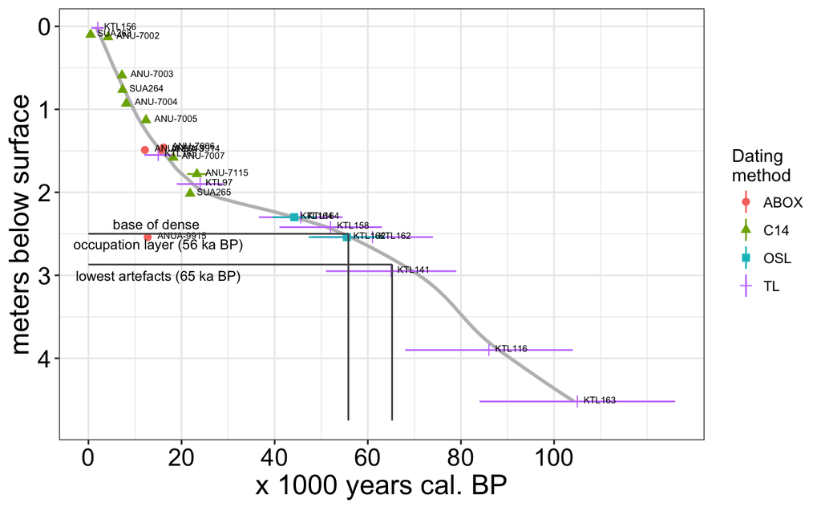

```r
chrono_data_plotted <- plot_chrono_data(chrono_data_tidied,
                        oldest_depth = chrono_data_interpolated$oldest_depth,
                        oldest = chrono_data_interpolated$oldest,
                        base_of_dense_depth = chrono_data_interpolated$base_of_dense_depth,
                        dense = chrono_data_interpolated$dense)
chrono_data_plotted
```

At the time of Roberts et al. (1998) publication and commentary no calibration curve was available for radiocarbon dates greater than 11 ka, and hence the issue of underestimation of calendar years could not be resolved. A calibration curve is now available back to 50 ka (Reimer et al. 2013). The IntCal13 calibration curve results in a calibrated age for the 13.39 ka age (ANU-7006) as 15,001  17,429 cal BP, overlapping at 1sd with the TL age of 15 ± 3 ka (KTL-165) at equivalent depth. Kamminga and Allens (1973) 18.04 ka age (SUA-265) calibrates to c. 22.4 - 21.0 ka, overlapping at 1sd with the TL age of 24 ± 5 ka (KTL-97) at equivalent depth. The 14.9 ka age (ANU-7007) provided by Roberts et al. (1998) calibrates to 18.5 - 17.8 ka, and remains within 1Ï of the TL age of KTL-97. These new calibrations show that conventional radiocarbon years do substantially under-estimate the ages of the sediments and that calendar ages show a strong correlation with luminescence ages.

### `plotting_slopes_chrono_data`

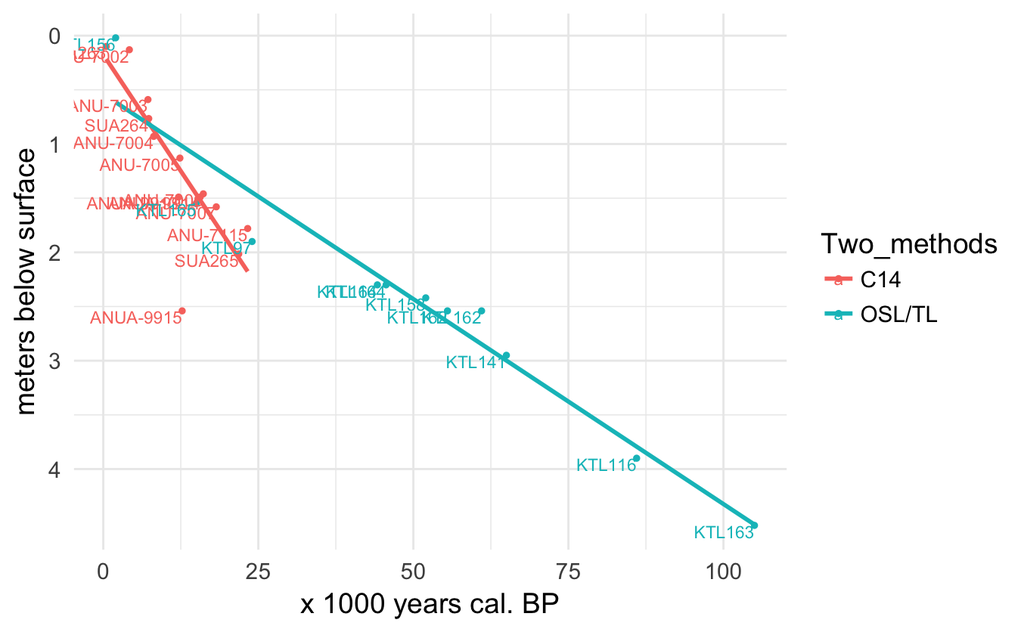

```r
chrono_data_slopes_plot <- plotting_slopes_chrono_data(chrono_data_tidied)
# show plot
chrono_data_slopes_plot$the_plot
```

Chech the structure of the `chrono_data_slopes_plot` output.

```r
str(chrono_data_slopes_plot, 1)
```

```
List of 2
 $ dates_1989:'data.frame': 24 obs. of  19 variables:
 $ the_plot  :List of 9
  ..- attr(*, "class")= chr [1:2] "gg" "ggplot"
```

Plotting the linear regression lines for OSL/TL ages against radiocarbon ages suggests that the slopes of the lines are not the same. We can explore this further by comparing the models directly.

```r
anova_p_value <- testing_slopes_chrono_data(chrono_data_slopes_plot$dates_1989)
```

Computing a linear model with depth and age using the two dating methods as a cross to test for interaction between them gives a significant difference, with a p-value of 0.011.

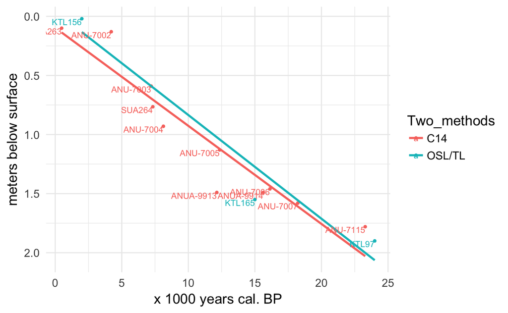

```r
ancova_p_values <- ancova_slopes_chrono_data(chrono_data_slopes_plot$dates_1989)
# show the plot
ancova_p_values$the_plot
```

If we restrict the sample to just the dates in the upper 2 m, which is the depth of the lowest in-sequence radiocarbon date (SUA-265), we can more robustly compare the ages from radiocabon and luminesensce methods.

In the ANCOVA model, age is modeled as the dependent variable with depth as the factor and dating method as the covariate. The summary of the results show a significant effect of depth (p = 0.00000), but no significant interaction between dating methods (p = 0.791). These results suggest that the slope of the regression between age and depth is similar for both dating methods.

```r
anova_p_values <- anova_slopes_chrono_data(ancova_p_values$upper, ancova_p_values$m2)
```

We can fit a more parsimonious model without the interaction to test for significant differences in slope. We can compare the two models for each dating method with ANOVA to assess if removing the interaction significantly affects the fit of the model. The result is that removing the interaction does not significantly effect the fit of the model. There is still no significant effect of dating method on the slope of the age-depth lines (p = 0.791)

[output not shown]

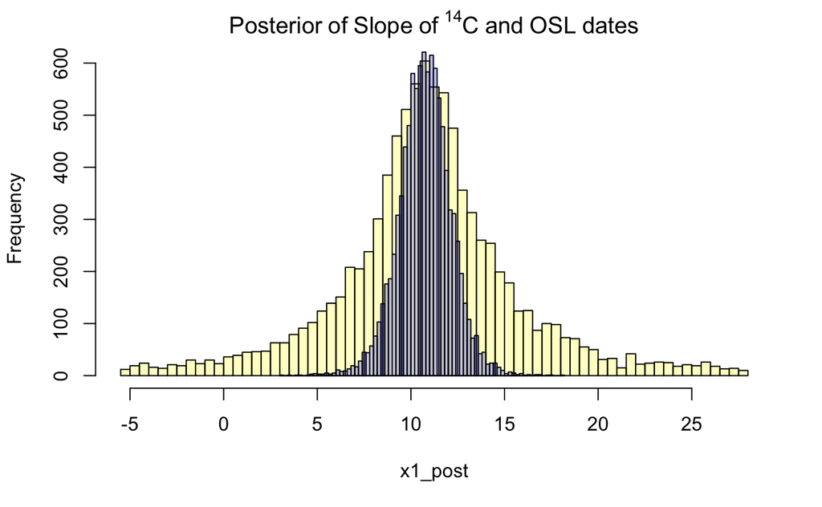

```r
bayes_values <- bayes_slopes_chrono_data(ancova_p_values$upper)
```

```r
# Warning - very time consuming, >30 min
# bayes_test_values <- bayes_test_slopes_chrono_data(bayes_values$x1_post, bayes_values$x2_post)
```

```r
# since the MCMC is quite time consuming,I've included the output
# from a run so we can use that rather than redo the analysis. To
# redo the analysis, simply run the code in the previous chunk.
load("data/slopes_test.rda")
# This requires the summary.BEST from BEST
library("BEST")
summary(slopes_test)
```

```
             mean  median    mode HDI%   HDIlo   HDIup compVal %>compVal
mu1       10.8219 10.8220 10.8231   95 10.7351 10.9060
mu2       10.7623 10.7623 10.7618   95 10.7358 10.7880
muDiff     0.0596  0.0598  0.0620   95 -0.0309  0.1482       0      90.4
sigma1     3.6205  3.6204  3.6230   95  3.5240  3.7115
sigma2     1.1386  1.1385  1.1386   95  1.1148  1.1625
sigmaDiff  2.4819  2.4818  2.4817   95  2.3938  2.5696       0     100.0
nu         4.6537  4.6485  4.6495   95  4.3116  5.0095
log10nu    0.6675  0.6673  0.6676   95  0.6352  0.7003
effSz      0.0222  0.0223  0.0233   95 -0.0108  0.0559       0      90.4
```

```r
best1 <- round(BEST:::summary.BEST(slopes_test)[3], 2)
best2 <- round(unname(BEST:::summary.BEST(slopes_test)[3, 5:6]),2)
```

Smith and Jones obtained several more radiocarbon dates that have not been previously published (Table 1), increasing the number of available radiocarbon ages for the site to 13. With the exception of one anomalous age from the base of the sequence already discussed above (ANUA-9915), the additional 14C ages provide a picture of consistent depth-age relationships between radiocarbon and luminescence techniques down to two meters below the surface (the depth of the lowest in-sequence radiocarbon date). A test of the difference between the correlation coefficients for the linear regression slopes for 14C and luminescence ages indicates no significant difference between slopes, indicating that both provide effectively identical age-depth relationships for the uppermost two meters of deposit (Bayesian estimation of difference in means = 0.06, 95% HDI = -0.03, 0.15, the interval includes zero, indicating no credible difference). Concerns over the degree of fit between 14C and luminescence chronologies for the upper half of the deposit can no longer be sustained (cf. Bowdler 1990; Hiscock 1990).

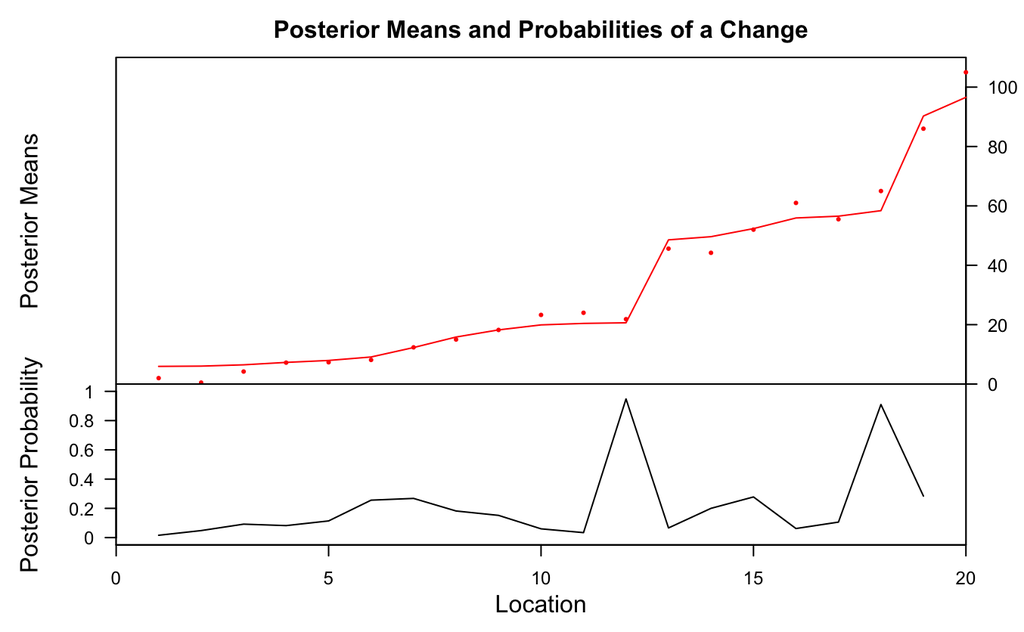

```r
#### bayesian change point analysis on sedimentation rates
bayes_cp_result <- bayes_cp_test(chrono_data_slopes_plot$dates_1989)
```

Bayesian change point analysis indicates that sedimentation rates slow substantially below 2.0 m to the base of occupation (posterior probability of change is 0.948 at 22 ka cal BP) and then accelerate again below the lowest occupation (posterior probability of change is 0.91 at 65 ka).

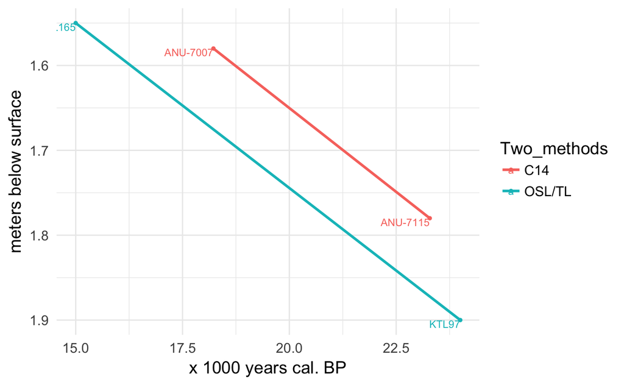

```r
# check 15  20 ka sedimentation rates
# examine slope from KTL97 through KTL165 compare C14 to OSL
# now limit for depth range KTL97 through KTL165
sed_rates_15_to_20_result <- sed_rates_15_to_20(chrono_data_slopes_plot$dates_1989)
# plot
sed_rates_15_to_20_result$the_plot
```

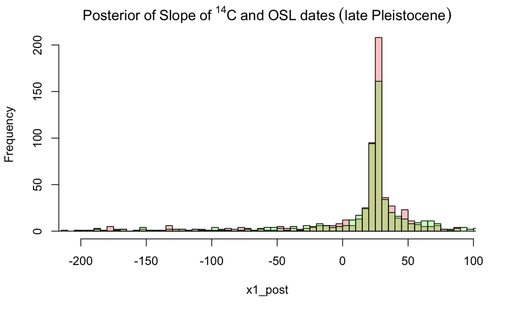

```r
bayes_slope_posteriors <- bayes_slope_difference(sed_rates_15_to_20_result$sub_OSL,
                                                 sed_rates_15_to_20_result$sub_C14)
```

```r
# rather time consuming, >30 min
# bayes_slope_difference_result <- bayes_slope_test(bayes_slope_difference_result$x1_post,
#                                                bayes_slope_difference_result$x2_post)
```

```r
# since the MCMC is quite time consuming,I've included the output
# from a run so we can use that rather than redo the analysis. To
# redo the analysis, simply run the code in the previous chunk.
load("data/slopes_test_sub.rda")
BEST:::summary.BEST(slopes_test_sub)
```

```
              mean   median      mode HDI%     HDIlo    HDIup compVal %>compVal
mu1       25.94944 25.94812 25.942351   95  2.55e+01 26.42176
mu2       25.73194 25.72959 25.731983   95  2.49e+01 26.54876
muDiff     0.21750  0.22006  0.252338   95 -7.46e-01  1.14991       0      67.6
sigma1     4.90146  4.88684  4.839097   95  4.20e+00  5.62274
sigma2     8.56242  8.53835  8.504374   95  7.36e+00  9.84656
sigmaDiff -3.66096 -3.64934 -3.705678   95 -5.14e+00 -2.26751       0       0.0
nu         1.00374  1.00257  1.000514   95  1.00e+00  1.01130
log10nu    0.00162  0.00112  0.000247   95  9.72e-09  0.00488
effSz      0.03137  0.03164  0.035904   95 -1.05e-01  0.16664       0      67.6
```

```r
# print(slopes_test_sub)
# plot(slopes_test_sub)
# windows()
# plotAll(slopes_test_sub, credMass=0.8, ROPEm=c(-0.1,0.1),
#         ROPEeff=c(-0.2,0.2), compValm=0.5)
# pairs(slopes_test_sub)
```

### Lithics

```r
# Now onto the lithic data...
lithics_data_cleaned <- clean_lithics_data(lithics_data)
```

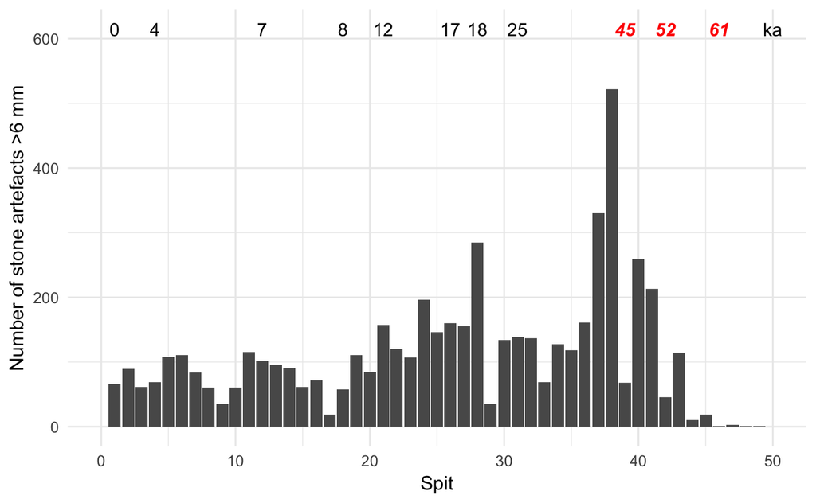

```r
lithics_data_plotted <- plots_lithics_data(lithics_data_cleaned,  bayes_cp_result$cal.date.lo)
lithics_data_plotted$p1
```

```r
# figures/Fig_6_lithics_over_time_from_1989_for_paper.svg
```

```r
lithics_rawmaterials_plotted <- plots_lithics_rawmaterials(lithics_data,
                                                           lithics_data_plotted$spit,
                                                           bayes_cp_result$cal.date.pr)
```

```
analogue version 0.17-0
```

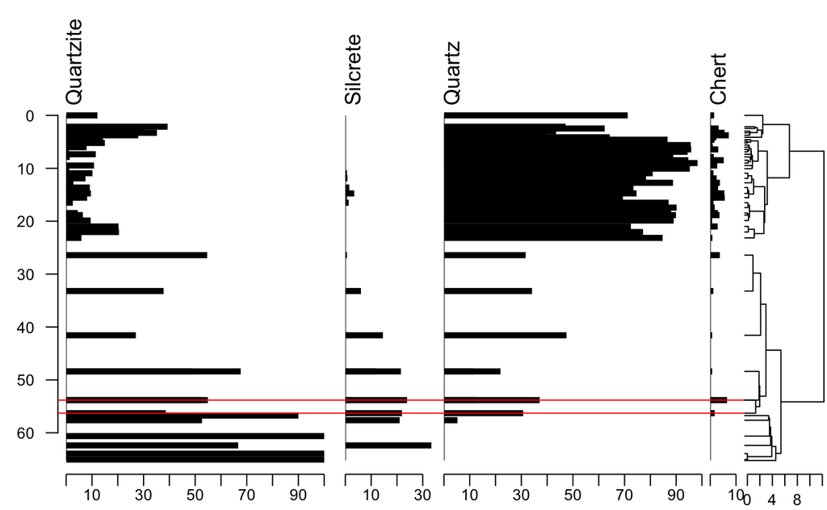

```r
lithics_rawmaterials_stratplotted <- stratiplot_lithics(lithics_rawmaterials_plotted$plot2)
```

```r
# figures/Fig_9_stratplot.png
```

```r
lens_differences_raw_plot <- lens_differences_raw()
```

[output not shown]

```r
raw_fish_pval <- formatC(round(lens_differences_raw_plot$raw_chi_fisher$p.value, 4), big.mark=",",format="f", drop0trailing = TRUE)
```

```r
lens_differences_tech_plot <- lens_differences_tech()
```

[output not shown]

```r
tech_fish_pval <- round(lens_differences_tech_plot$tech_chi_fisher$p.value, 3)
```

```r
lens_tech_and_raw_plot <- combine_lens_plots(lens_differences_tech_plot$p1,lens_differences_raw_plot$p1)
lens_tech_and_raw_plot
```

null device 1

```r
cat("<p><img src='figures/Fig_10_combine_lens_plots.png', width='100%'></p>")
```

[figure not shown]

Chi square tests indicate that the differences in raw material proportions between all three assemblages are highly significant (p = 0.0005), although the differences in technological composition are not significant (p = 0.605), most likely due to small sample size (n = 10 for types in the assemblage below the lens).

## Shellfish

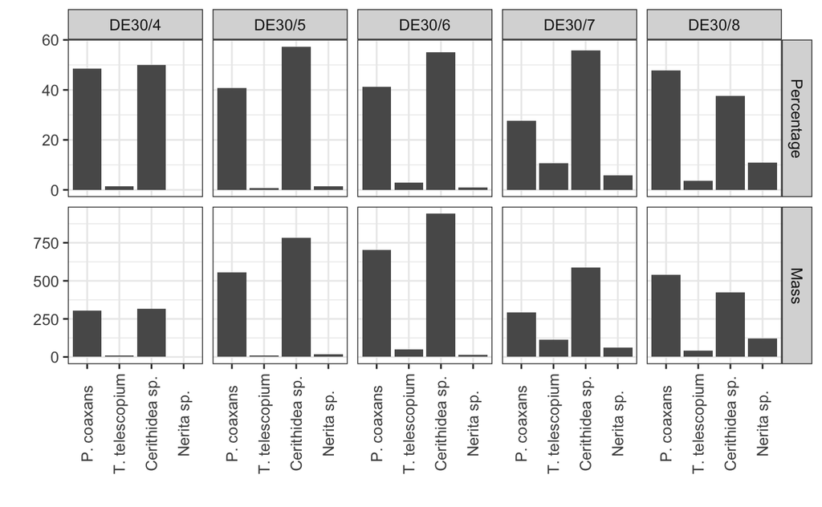

```r
shell_data_plotted <- plot_shell_data()
shell_data_plotted
```